# Testing session protocol

Yiming Qian, Andrea Seisler, & Rick Gilmore

2020-02-26 10:33:56

## Before participant arrives

- Please arrive *10 minutes prior* to the participant testing time.
- Check with Andrea/Yiming to see if there have been any cancellations or check the green folder with the daily schedule in it.
- If the scheduled study is still on the books, proceed as follows.

### Set-up for Vision Screening

#### Preparation

Materials for vision screening are stored on the table next to Andrea’s office.

- Make sure the black tape is on the floor 10ft from the HOVT Snellen Acuity Chart which is on the door to 503B
- Place Stereo Acuity Test and Glasses on table
- Place Color Vision Test on table
- Place the Vision Screening Score Sheet on the table

### Set up for computer-based tasks

#### Stimuli Computer

- *Log into Data Collection Computer*
  - Turn on the power of the data collection computer
  - Turn on the CRT monitor in 503B
  - Log-in (use your indiviual PSU login)
- Check Speaker/Headphone Volume
  - On the right side of the task bar, make sure that the volume is ON
    - If the volume is OFF click to turn ON
    - Ensure volume level is set at 68%
- *Start Psychopy*
  - Click **PsychoPy** icon on Task Bar
  - Open Studies:
    - File > Open Recent OR
    - File > Open > Windows(C:) > Experiment > PsycoPy-Stimuli
- *Double-check monitor settings within Windows*
  - Click Settings (‘gear’) icon on Task Bar

[figure not shown]

  - Choose **System**
  - Choose **Display**
  - Choose **Advanced display settings** (You may need to scroll down to see this)
  - Make sure the window that appears has the following Settings

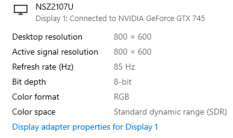

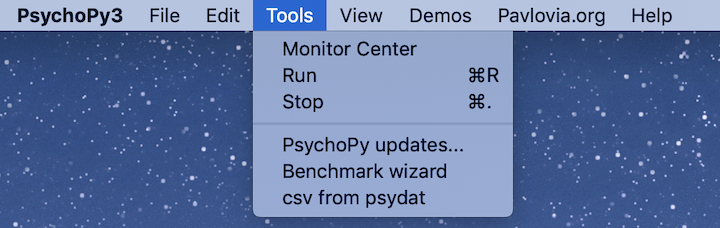

  - View Settings, they should be as follows

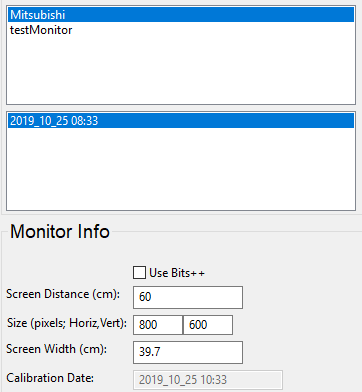

#### Survey Computer

- Log-in to survey computer with your individual PSU login
- Load page with surveys: https://pennstate.qualtrics.com/jfe/form/SV_5AoCVwYH7ZsXFQh. **UPDATED 2020-1-23**.

#### Pick Participant ID

- Participant IDs are listed on the whiteboard in the lab.
- Please select the smallest number
  - Enter this into the Qualtrics Survey
  - Enter this into the Temporal duration threshold task
  - Enter this into the Contrast sensitivity task
  - Write this on the Vision Scoring Sheet
- Cross this number out with the brown marker on the whiteboard.

#### Daily Schedule

- The Daily Schedule will be located in the green folder

### After participant arrives

#### Welcome participant

Say:

> “*Welcome to the brain, behavior, and development lab. Are you here for the study about individual difference of motion perception?*”

Close the door. If the participant answers yes, say:

> “*Great. You can sit in this chair and put your coat and bags beside you.*”

> “*Do you have your cell phone or is it with your bag/coat? If you have your cell phone, please place it with your bag/coat.*”
- Store coat on back of main door and bags by the file/bookcase.

> “*Are you <NAME OF PERSON ON SONA SYSTEMS SITE SCHEDULED FOR THIS SESSION>?*”
- If the participant answers yes, say:

> “*Ok. We want to make sure that you get credit for participation. Please sit here for the first portion of the study.*”
- Have the person sit at the computer where the survey will be taken.

#### Begin the survey

Conduct the implied verbal consent.

> “*Welcome. Today you are going to participate in a set of questionnaires, two computer visual tasks and a few vision screening measures. Your participation is voluntary and you may decide to stop at any time. You do not have to answer any questions that you do not want to answer. You will receive course credit for your participation. You may review the consent form on the screen in front of you. Do you have any questions?*”

Once the consent is complete (It means the participant clicks to the next page), enter participant ID

- Following the consent page, there is a Participant ID blank spot on the top of visual acuity test page. Please use the smallest number available on the white board. *Take a note* of this participant ID in “Penn State Vision Screening Score Sheet”. Enter this number into the Qualtrics Survey and each of the computer tasks.
- Do not choose a number before the participant arrives.
- When you use a Participant ID from the white board, please cross it out with the brown dry erase marker. All used numbers will be erased at the end of the day.

Then say,

> “*Great. Now we’d like to move on to the first vision screening test. Could you stand behind this line?*”

### Complete pattern visual acuity testing

##### Procedure

- Have participant stand 10 feet away from the chart on the wall (black tape on the floor)
- Ask the participant to start with the top line and have the participant read the first symbols in every line in descending order

> “Could you read the first symbols in each line for me from the top to bottom?”
- If they miss a letter, circle it on the score sheet.
- Move back up one line and ask the participant to identify all the optotypes on that line. If the participant identifies all symbols correctly, go to the next line with smaller optotypes and ask the participant to identify all optotypes on the line.

> “Could you read all the symbols in this line? And this line?”
- Their visual acuity will be the one that matches the line on which 50% (3 of 5, 4 of 6) of the symbols are identified correctly.

##### Report results

- Log the answer to each item on the score sheet.
- Log the acuity for the participant in terms of 10 ft (e.g. 10/10)
- Report the result into Qualtrics

### Stereo acuity and color vision tests

> “*Thank you.We are going to complete two more short vision tests. Please come sit over here at this desk.*”

Escort participant to desk.

#### Color Test

##### Procedure

- The examination should be done indoors with bright, natural illumination of more than 300 lux ([lux](https://en.wikipedia.org/wiki/Lux) is a unit of illuminance. 320-500 lux is equivalent to office lighting.
- The plates should be held at a distance of 50 - 75 cm (20-30 inches)

Say:

> “This test assesses your color vision. Look at this picture and tell me what you see.” “Now trace the curve.”
- The first exam:
  - *Skip: Examiner shows the participant plate 1 or 2, tracing the red line. Recognized as “circle”, “square”, or some other design.
  - Plate 3 and 4. The participants are required to say outloud “circle”, “square”, or some other design. If the shape is correctly recognized, mark as normal.If the shape is not correctly recognized, mark as abnormal.
- The second exam:
  - Skip: Examiner shows the participant plate 5. Recognized as a curve line.
  - Plate 6: In tracing the winding line between the upper left mark x and lower right mark x, the normal traces the red curve, but the abnormal usually trace the blue.
  - Plate 7: In tracing the winding line between the upper left mark x and lower right mark x, the normal traces the upper green curve, but the abnormal usually trace the lower red curve.
  - Plate 8: In tracing the winding line between the upper left mark x, the normal can trace upper and lower curve and come back to the starting mark. In case of abnormal color vision, some can trace either contour.

When the participant is finished, say:

> “Great. Thank you.”

##### Report results

- Log the answer to each item on the score score sheet.
- Those who can not recognize any curve in plate 8 at all, or any lower curve are definitely abnormal.
- They might be abnormal if they misjudge more than 3 plates among plates 3,4,6,7
- If they misjudge 1-2 plates among plates 3,4,6,7, it is better to re-examine him in details from plate 1-8.
- Report the result into Qualtrics

#### Stereo Vision Test

##### Procedure

- Have the participant put the stereo glasses on.
- Have the participant sit at the desk and hold the book at arms length approximately perpindicular to their line of sight.
- Provide good light, make sure the pictures maintain the proper axis of polarization before the participants at 15 minutes of arc at a distance of 16 inches.
- Only do the circle test. Point to each item on the left hand side of the page going left to right and up to down.
- Start with No.1.

Say:

> “*This test assesses your stereoacuity. Do you see the butterfly? Can please trace it? Look at each of the four circles and tell me which one seems to come out closer to you-top, bottom, right, or left.*”

Continue until participant gives up trying, or making two successive mistakes. - Some participants may develop this perceptual response slowly. So let them study it for a while or let them change the viewing angle, if needed.

##### Report results

- Log the answer to each item on the score sheet.
- Record the level of stereopsis into Qualtrics at the last one chosen correctly.
- write down the performance of these three visual tests in qualtrics.

### Questionnaires

> “*Thank you. Now we’d like to move on to the questionnaires. You can follow the instructions and finish the survey. Feel free to ask me if you have any questions. Let me know when you finish it.*”
- Have the participant sit back down at the computer.
- Let the participants finish the questionnaire.
- Answer the questions if the participants have any, when they work on the questionnaires.
- But be in careful in the hobby page, spatial and verbal page, because the time is recorded. The page will vanish when the time has passed. So, depending on the nature of the questions, answer them fast and emphasize the time is recorded in this page.

After answering the question, say:  
>“*Be aware: there is a time limit for this page.* ”

- If the participant has questions in the instruction page of the hobby test, spatial and verbal test, answer carefully and make sure the participants understand.
- After the participants finish the questionnaire, ask them if they need a little break. If the participant wants to keep going, lead them to the test room

Say:

> “*You have finished this part. Next you have two computer tasks. Do you want to continue or have a little break?*”

### Set-up for computer-based tasks

- Guide participant to the testing room.
- Have them sit in the chair.
- Adjust the monitor and participant position.
  - The monitor should be located **60cm** from the bridge of the nose on the participant.
  - *place the rear legs of the chair to approximately align with the black tape on the wall*
  - Measure the 60cm and adjust the chair accordingly
  - The chair height should be set so the participant is looking in the middle of the screen.
- Guide the participant to use the arrow keys for responses and the space bar to advance the screen.
- *check with participants that they do not bring the cell phone to the dark room*

Say:

> “*Please come to this room for the behavioral tests. Sit in the chair. Could I move the chair a little bit? I want to make sure every particpant is the same distance from the computer screen. Please sit up straight and have your back touching the chair. Do not move your chair.*”

> “*Please do your best and focus on the center of the screen during these tasks.*”

### Run computer-based tasks

#### Select run order

The order of the computer experiments will be randomized across participants based on the participant ID entered into Qualtrics.

- run the *temporal duration threshold task* FIRST (Murray et al.) if the ID number is *EVEN*.
- run the *contrast sensitivity task* FIRST (Abramov et al.) if the ID number is *ODD*. *Record the task run first on the experiment run log.*

#### Temporal duration threshold task (Murray et al.)

**Run FIRST if Participant ID = EVEN number**

Preferred Method of Running Study

- Click on the `motion-temporal-threshold.py-Shortcut` on your Desktop

*Alternate method of Running Study*

- Open PsychoPy by clicking on the icon located on the desktop.  
- When PsychoPy opens, open the file for this experiment. - From the `File` menu, select the `Open Recent...` command and select the `motion-temporal-threshold.py` file. - When the file opens, run the experiment by pressing press the green (running person) button.  
- **Be careful not to type in the programming window.**

- Experimenters need to fill in the participant ID and gender.
  - A pop-up window will appear.
  - Enter participant ID. Make sure it is the same ID that you entered into Qualtrics.
  - Enter gender (enter “f” or “m”, no upper case) in the pop window, and press the `Ok` button to enter the data.
- Speak to the participant

> “In this task, you need to detect the moving direction of a small patch of stripes. The time the patch appears on the display will get shorter and shorter. Our goal is to find out the shortest duration you need to detect the direction of motion.”

> “Which hand do you prefer to press the arrow keys?”

> “Put your fingers of your prefered hand on the left and right arrow keys. **You’ll press the LEFT arrow if you see motion to the left and the RIGHT arrow if you see motion to the right.** If you aren’t sure, make your best guess.”

> For the left-handed: “You could press this ENTER key on the right side to proceed instead of SPACE BAR.”

> "On the computer screen, you will see a black dot at first. When the black dot appears, press the SPACE BAR to start the trial. Then you will see the patch. Make responses of LEFT or RIGHT when the white dot appears.

> “Remember, accuracy is more important than speed. Please take your time.”

> “Do you have any questions right now? I will leave you in the room. Follow the instructions on the screen. Call me when you finished this part.”
- close the door for participants

#### Contrast sensitivity task (Abramov et al.)

**Run FIRST if Participant ID = ODD number**

Preferred Method of Running Study

- Click on the `motion-temporal-threshold.py-Shortcut` on your Desktop

*Alternate method of Running Study*

- Open PsychoPy by clicking on the icon located on the desktop.  
- When PsychoPy opens, open the file for this experiment.  
- From the `File` menu, select the `Open Recent...` command and select the `motion-temporal-threshold.py` file. - When the file opens, run the experiment by pressing press the green (running person) button.  
- **Be careful not to type in the programming window.**

- Experimenters need to fill in the participant ID and gender.
  - A pop-up window will appear.
  - Enter participant ID. Make sure it is the same ID as that in qualtrics.
  - Enter gender (enter “f” or “m”, no upper case) in the pop window, and press the `Ok` button to enter the data.
- Speak to the participant

> “You will see a small patch of black and white stripes which are horizontal or vertical.Be careful. You need to detect the DIRECTION OF THE STRIPES not the moving direction. (Show the example pictures put in the left side of desk). You can **press the LEFT key if you see the stripes are horizontal, DOWN key if you see the stripes are vertical.** But if you aren’t sure, just guess.”

> “The luminance of the stripes will get smaller and smaller. Our goal is to find out the smallest luminance that you need to detect the direction of stripes.”

> “Which hand do you prefer to press the arrow keys?”

> “Put your fingers of your prefered hand on the left and down keys. You’ll press the LEFT key if you see HORIZONTAL stripes and the DOWN key if you see VERTICAL stripes. If you aren’t sure, make your best guess.”

> For the left-handed: “You could press this ENTER key on the right side to proceed instead of space bar.”

> “Remember, accuracy is more important than speed. Please take your time.”

> “Do you have any questions right now? I will leave you in the room. Follow the instructions on the screen. Call me when you finish this part.”
- close the door for participants

## After session ends

### Thank participant

- After the participant finishes all the tests, thank him/her.

> “*These are all the tasks for today. Thank you for participation. We appreciate your time. Do you have any questions?*”
- Answer any questions the participant might have. You may direct them to Yiming or to Dr. Gilmore if you are unable to answer the question.
- If the participant ask the purpose of this study, read the debrief

#### debrief

"In this study, the visual acuity test, color vision test and stereo vision test are conducted to make sure you have normal vision to detect the motion in short period or low luminance.

You also have done two computer tests, which examine your performance in motion perception. In this study, we want to investigate whether or how motion perception is correlated with individual’s verbal ability, spatial ability, or personal interests. "

> “*Okay. The principal investigator will give you the credit by the end of the next business day.*”
- Say bye to participants

### Give participant credit on SONA

- Yiming or Andrea will assign credit in SONA.

### Clean-up

- Mark on the daily schedule sheet in the green folder if:
  - the participant was Present or a No Show
  - the number used for that participant if Present
- Clean keyboard, mouse and table.

### Data Export

- Andrea or Yiming will copy the data to Box:
  - Frequency at the end of each day or the morning before data collection starts
    - When this is complete a note should be written into the `study-sex-differences` discord channel and include the date the data were copied.
  - temporal duration threshold task data gets copied to: Box > Project_Sex_difference_on_Motion_Perception > data > raw_data> motion_temporal_threshold_data’
  - contrast sensitivity task data gets copied to: Box > Project_Sex_difference_on_Motion_Perception > data > raw_data> contrast_sensitivity_task_data’